# **How to plot**

## **Authors:**

**Abdullah A. Fahad** (a.fahad@nasa.gov) \ **Tahmidul Azom Sany** (tsany@gmu.edu) \ **Torikul Islam Sanjid** (torikul.sanjid@gmail.com) \ **Md Tashin Ahammad** (tashinahammad.03@gmail.com) \

**Suggestions 23 june**

- global plot -- Any data (SST better) with cartopy
- upadate omi

# 1. Basic Plotting with Matplotlib (Scatterplot, Barplot, Heatmap, Boxplot, etc.)

## What is Matplotlib?

Matplotlib is a Python library for creating high-quality visualizations and plots of data.It is the most well-known of all the python visualization packages and provides a variety of capabilities such as:

- Matplotlib can gernerate high-quality graphics in a number of file types including PDF, SVF, JPG, PNG, BMP and GIF.
- Matplotlib include line plots, scatter plots, histograms, bar charts, pie charts, and box plots.
- Additionally, it enables 3D charting, and many additional libraries, such as pandas and Seaborn, have been built on top of it to provide access to Matplotlib's capabilities with less code.

### Some basic functions

Let's have a look at some of the basic function that are often used in matplotlib.

| Function | Description |
| --- | --- |
| plt.plot() | Creates line plots to represent data. |
| plt.scatter() | Generates scatter plots to display individual data points. |
| plt.bar() | Creates bar plots to visualize categorical data. |
| plt.hist() | Generates histograms to display the distribution of numerical data. |
| plt.boxplot() | Creates boxplots to show the distribution and outliers of a dataset. |
| plt.pie() | Generates pie charts to display proportions or percentages of categorical data. |
| plt.imshow() | Displays images or heatmaps using arrays of data. |
| plt.show() | it displays the created plots |
| plt.xlabel() | This function is used to add a label to the x-axis of the plot. |
| plt.ylabel() | This function is used to add a label to the y-axis of the plot. |
| plt.title() | This function is used to add a title to the plot. |
| plt.legend() | Adds a legend to the plot to identify plotted elements. |
| plt.xticks() | This function is used to set the tick locations and labels for the x-axis. |
| plt.yticks() | This function is used to set the tick locations and labels for the y-axis. |
| plt.grid() | This function is used to add a grid to the plot. |
| plt.xlim() | Sets the limits for the x-axis. |
| plt.ylim() | Sets the limits for the y-axis. |
| plt.annotate() | it is use to write comments on the graph at the specified position |
| plt.figure(figsize = (x, y)) | whenever we want the result to be displayed in a separate window we use this command, and figsize argument decides what will be the initial size of the window that will be displayed after the run |
| plt.subplot(r, c, i) | it is used to create multiple plots in the same figure with r signifies the no of rows in the figure, c signifies no of columns in a figure and i specifies the positioning of the particular plot |

These are some common functions used in matplotlib plotting.

### Importing Matplotlib

To use matplotlib we need to import it.We will use standard shorthand for matplotlib imports to make things simpler.

```python
import matplotlib.pyplot as plt
```

Here we have imported the **`pyplot`** module from the **`matplotlib`** library as **`plt`**.This is a common convention to simplify the usage of **`pyplot`** functions throughout the code.

Basically, we'll be using **`plt`** instead of **`matplotlib.pyplot`**

### Scatterplot

**Step by step guide to create a scatterplot:**

**Step 1:**

Firstly, we'll import the necessary packages.We'll use `matplotlib` for plotting and `numpy` to produce data.

**Step 2:** Then we'll gernerate random data using numpy to plot.Here,we'll use Numpy's **`random.normal()`** function to generate 100 random numbers for two variables:**`x`** and **`y`**

**Step 3:** In this step we'll plot the data using matplotlib's **`scatter()`** function to create a scatter plot of the **`x`** and **`y`** data points.

**Syntax of scatterplot :**

```
matplotlib.pyplot.scatter(x, y, s=None, c=None, marker=None, cmap=None, norm=None, vmin=None, vmax=None, alpha=None, linewidths=None, *, edgecolors=None, plotnonfinite=False, data=None, **kwargs)
```

**Step 4:** Finally, we use the **`show()`** function to display the plot.

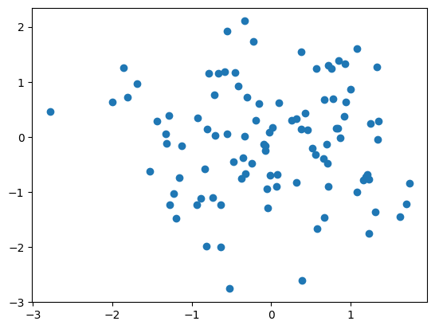

```python
# import packages
import matplotlib.pyplot as plt
import numpy as np

# generate random data
x = np.random.normal(size=100)
y = np.random.normal(size=100)

# plot the data
plt.scatter(x, y)

# show the plot
plt.show()
```

### Barplot

**Step 1:** Firstly, we'll import the necessary packages.We'll use `matplotlib` for plotting and `numpy` to produce data.

**Step 2:**Then we'll gernerate random data using numpy to plot.Here,we'll use Numpy's NumPy's **`random.randint()`** function to generate a list of 8 random integers between 1 and 150.

**Step 3:** In this step we'll use the **`bar()`** function from pyplot to create a bar graph. The **`range(len(data))`** is used to generate a sequence of indices corresponding to each data point, and **`data`** represents the height of each bar. The **`color`** parameter is set to **'#900C3F'** to specify the color of the bars.

**Syntax of bar plot:**

```
matplotlib.pyplot.bar(x, height, width=0.8, bottom=None, *, align='center', data=None, **kwargs)
```

**Step 4:**Finally, we use the **`show()`** function to display the plot.

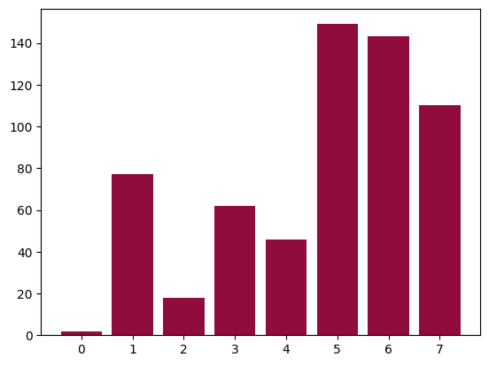

```python
#Importing packages
import matplotlib.pyplot as plt
import numpy as np
#Creating random list of 8 numbers.
data = list(np.random.randint(1, 150, 8))
#Plotting the horizontal bar.
plt.bar(range(len(data)), data, color='#900C3F')
#showing the plot
plt.show()
```

### **we can also create a horizontal bar chart.**

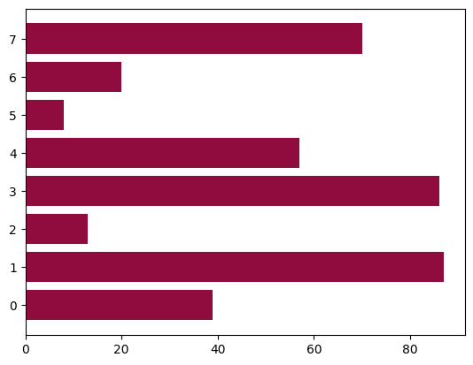

```python
#Importing packages
import matplotlib.pyplot as plt
import numpy as np
#Creating random list of 8 numbers.
data = list(np.random.randint(1, 150, 8))
#Plotting the horizontal bar.
plt.barh(range(len(data)), data, color='#900C3F')
#showing the plot
plt.show()
```

### Heatmap

A heatmap is a graphical representation of data where values are represented as colors in a two-dimensional grid. Heatmaps are particularly useful for visualizing patterns, correlations, or distributions in data matrices.

Let's see a heatmap

[figure not shown]

**Explanation:**

Here we see a heatmap representing the harvest data of local farmers. Each cell in the heatmap corresponds to a combination of a vegetable and a farmer, with the color intensity representing the harvest amount. The color intensity of each cell gives us the values of harvest with help of color bar included.

#### **Let's make a simple Heatmap:**

**Step by step guide to create heatmap:**

**Step 1:** Firstly, we'll import the necessary packages.We'll use `matplotlib` for plotting and `numpy` to produce data.

**Step 2:**Then we'll gernerate random data using numpy to plot.Here,we'll use Numpy's NumPy's **`np.random.rand()`** function to generate a 10x10 random matrix.

**Step 3:** In this step we'll use the **`imshow()`** function from pyplot to create a heatmap.The **`data`** matrix is used as the input data. The **`cmap`** parameter is set to **`autumn`** to use the autumn color map.

**Syntax of Heat map:**

```
matplotlib.pyplot.imshow(X, cmap=None, alpha=None)
```

```
X :- this is input data matrix which is to be displayed
cmap :- Colormap we use t0 dispay the heatmap
alpha :- it specifies the opacity or transpiracy of the heatmap
```

**Step 4:** a color bar is then added.

**Step 5:**we set the title and labels.

**Step 6:**Finally, we use the **`show()`** function to display the plot.

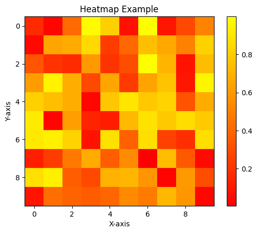

```python
import matplotlib.pyplot as plt
import numpy as np

# Generate random data
data = np.random.rand(10, 10)  # Generate a 10x10 random matrix

# Create a heatmap
plt.imshow(data, cmap='autumn')

# Add a color bar
plt.colorbar()

# Set title and labels
plt.title('Heatmap Example')
plt.xlabel('X-axis')
plt.ylabel('Y-axis')

# Show the plot
plt.show()
```

### Boxplot

A boxplot also known as a box and whisker plot is a graphical representation of the distribution of a dataset.

- It can summarizes key statistical measures such as the median,quartiles, and potential outliers. *The boxplot provides a compact way to visualize the spread and skewness of the data.

**It has the following component:**

[figure not shown]

**Box:** The box represents the interquartile range (IQR), which contains the middle 50% of the data. The bottom edge of the box represents the 25th percentile (lower quartile), while the top edge represents the 75th percentile (upper quartile). The line inside the box represents the **Median**.

**Whiskers:** The whiskers extend from the box to the minimum and maximum non-outlier data points. They give an idea of the range of the dataset, excluding any outliers.

**Outliers:** Individual data points that are considered outliers are plotted as individual points outside the whiskers. They are typically defined as points that fall outside a certain multiple of the IQR from the edges of the box.By default, the range is set to 1.5 times the IQR.

**Step by step guide to create a boxplot:**

**Step 1:** Firstly, we'll import the necessary packages.We'll use `matplotlib` for plotting and `numpy` to produce data.

**Step 2:**Then we'll gernerate random dataset using numpy to plot.Here,we'll use Numpy's NumPy's **`random.normal()`** function where the `loc` parameter specifies the mean of the distribution, which is set to 0 in this case. The `scale` parameter specifies the standard deviation of the distribution, which is set to 1. The `size` parameter determines the number of data points in the dataset, which is set to 100.Then we added some outliers to data and created the final data.

**Step 3:** In this step we'll use the **`boxplot()`** function from pyplot. The **`data`** array is passed as the argument, which contains the dataset to be visualized.

**Syntax of boxplot:**

```
matplotlib.pyplot.boxplot(x, notch=None, sym=None, vert=None, whis=None, positions=None, widths=None, patch_artist=None, bootstrap=None, usermedians=None, conf_intervals=None, meanline=None, showmeans=None, showcaps=None, showbox=None, showfliers=None, boxprops=None, labels=None, flierprops=None, medianprops=None, meanprops=None, capprops=None, whiskerprops=None, manage_ticks=True, autorange=False, zorder=None, capwidths=None, *, data=None)
```

**Step 4:**We add title and labels.

**Step 5:**Finally, we use the **`show()`** function to display the plot.

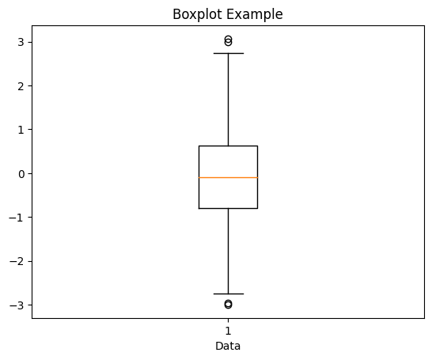

```python
import matplotlib.pyplot as plt
import numpy as np

# Generating random data
data = np.random.normal(loc=0, scale=1, size=100)

# Adding outliers
outliers = np.array([-3, 3])  # Example outliers
# Final data
data_with_outliers = np.concatenate((data, outliers))

# Create a boxplot
plt.boxplot(data_with_outliers)

# Set title and labels
plt.title('Boxplot Example')
plt.xlabel('Data')

# Show the plot
plt.show()
```

# 2. Cartopy and Map plotting

Cartopy is a Python package designed for geospatial data processing in order to make it easier to work with and analyze data that is related to the Earth's surface. It is built on top of several other popular scientific Python packages such as NumPy, Matplotlib, and Shapely, and provides a way to create maps, plot data on maps, and perform various geographical data analysis tasks.

Please note that when using cartopy in colab, it may sometimes crash. To avoid errors, please run the following cell. You can ignore the contents of the cell, and simply copy and paste the code whenever you need to use cartopy. After successfully installing all necessary components, please restart the runtime.

`Runtime --> Restart Runtime --> do not run again after restart`

```python
# Run this cell when you are in colab and then restart runtime
# Do not worry about this cell, you can always copy paste

!apt-get install libproj-dev proj-data proj-bin
!apt-get install libgeos-dev
!pip install cython
!pip install cartopy

!apt-get -qq install python-cartopy python3-cartopy
!pip uninstall -y shapely    # cartopy and shapely aren't friends (early 2020)
!pip install shapely --no-binary shapely
```

[output not shown]

```python
# importing libraries

import warnings
warnings. filterwarnings("ignore")

import matplotlib.pyplot as plt

# importing cartopy
import cartopy.feature as cf
import cartopy.crs as ccrs
import cartopy.mpl.ticker as cticker
from cartopy.util import add_cyclic_point
```

Let's start by creating a basic map using cartopy. To do this, we first need to define an `axes` and a `projection`. Once the projection is defined, we can add coastlines to the map, specifying the linewidth and color. We'll delve deeper into `projections` later on.

```
<cartopy.mpl.feature_artist.FeatureArtist at 0x7ff02c14e3b0>
```

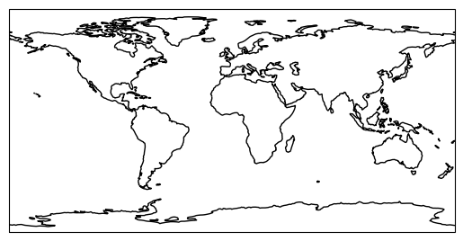

```python
map = plt.axes(projection=ccrs.PlateCarree()) # defining axes and projection* and assigned it to `map`
map.coastlines() # add coastlines
```

#### Add Features to the Map

We add features by calling the `add_feature()` method on-axis object and passing a feature object available from the `cartopy.feature` module.

We can add the following features (part of `cartopy.feature`) to our map:

- `COASTLINE`: Adds coastline around all continents.
- `LAND`: Adds land on top of world map.
- `LAKES`: Adds big lakes of the world.
- `BORDERS`: Adds country borders for the whole world.
- `OCEAN`: Adds ocean with a color.
- `RIVERS`: Adds big rivers of the world.

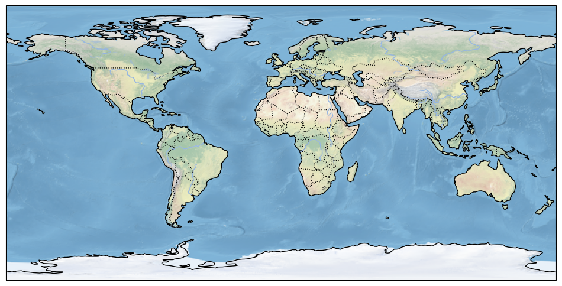

```python
# Adding more features and add stock images
plt.figure(figsize=(12,12))
map4 = plt.axes(projection=ccrs.PlateCarree())

map4.add_feature(cf.LAND)
map4.add_feature(cf.OCEAN)
map4.add_feature(cf.COASTLINE)
map4.add_feature(cf.BORDERS, linestyle=':')
map4.add_feature(cf.LAKES, alpha=0.5)
map4.add_feature(cf.RIVERS)

map4.stock_img() # try comment this
```

#### Regional Map

Need to provide the longitude and latitude ranges as arguments of the `set_extent` method on the axes object:

```
ax.set_extent([min_lon, max_lon, min_lat, max_lat])
```

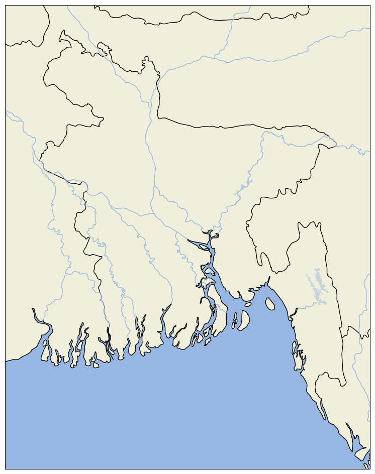

```python
# Cropping the map with set_extent
plt.figure(figsize=(12,12))
map5 = plt.axes(projection=ccrs.PlateCarree())

map5.add_feature(cf.LAND)
map5.add_feature(cf.OCEAN)
map5.add_feature(cf.COASTLINE)
map5.add_feature(cf.BORDERS, color='k') # you can also change color, linewidth etc
map5.add_feature(cf.LAKES, alpha=0.5)
map5.add_feature(cf.RIVERS)

map5.set_extent([87.5, 93, 20, 27]) # define the boundary
```

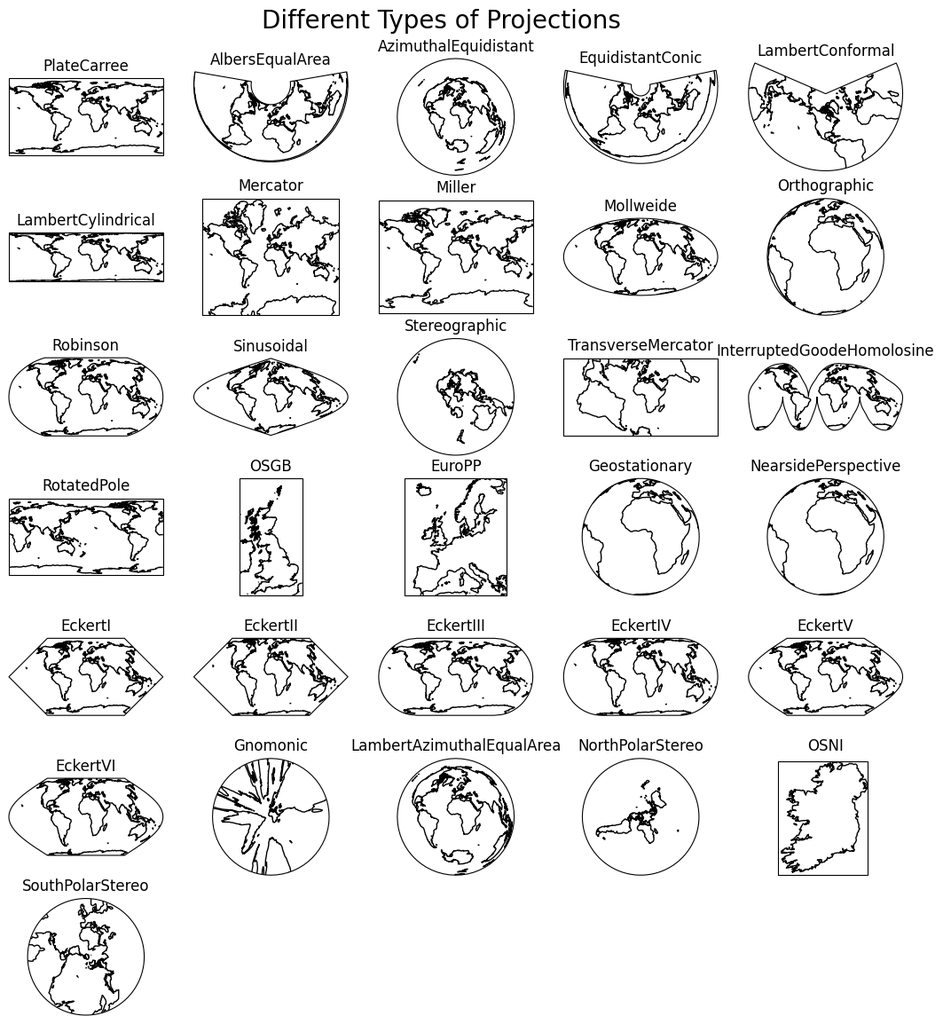

```python
# Do not worry about this cell, you will almost never need it
fig = plt.figure(figsize=(13, 14))
fig.suptitle('Different Types of Projections', fontsize=20, y=0.92)

projections = {'PlateCarree': ccrs.PlateCarree(), 'AlbersEqualArea': ccrs.AlbersEqualArea(),
               'AzimuthalEquidistant': ccrs.AzimuthalEquidistant(), 'EquidistantConic': ccrs.EquidistantConic(),
               'LambertConformal': ccrs.LambertConformal(), 'LambertCylindrical': ccrs.LambertCylindrical(),
               'Mercator': ccrs.Mercator(), 'Miller': ccrs.Miller(), 'Mollweide': ccrs.Mollweide(),
               'Orthographic': ccrs.Orthographic(), 'Robinson': ccrs.Robinson(), 'Sinusoidal': ccrs.Sinusoidal(),
               'Stereographic': ccrs.Stereographic(), 'TransverseMercator': ccrs.TransverseMercator(),
               'InterruptedGoodeHomolosine': ccrs.InterruptedGoodeHomolosine(),
               'RotatedPole': ccrs.RotatedPole(), 'OSGB': ccrs.OSGB(), 'EuroPP': ccrs.EuroPP(),
               'Geostationary': ccrs.Geostationary(), 'NearsidePerspective': ccrs.NearsidePerspective(),
               'EckertI': ccrs.EckertI(), 'EckertII': ccrs.EckertII(), 'EckertIII': ccrs.EckertIII(),
               'EckertIV': ccrs.EckertIV(), 'EckertV': ccrs.EckertV(), 'EckertVI': ccrs.EckertVI(),
               'Gnomonic': ccrs.Gnomonic(),
               'LambertAzimuthalEqualArea': ccrs.LambertAzimuthalEqualArea(),
               'NorthPolarStereo': ccrs.NorthPolarStereo(), 'OSNI': ccrs.OSNI(),
               'SouthPolarStereo': ccrs.SouthPolarStereo()}

for index, projection in enumerate(projections.items()):
    ax = fig.add_subplot(7, 5, index+1, projection=projection[1])
    ax.coastlines()
    ax.set_title(projection[0])
```

```python
from google.colab import drive
drive.mount('/content/drive')
```

```python
# Load the precipitation and temperature data from NetCDF files
data = xr.open_dataset("/content/drive/MyDrive/DataSets/ERA5_monthly_global_precipitation_temp.nc").load()
data
```

```
<xarray.Dataset>
Dimensions:    (longitude: 1440, latitude: 721, time: 12)
Coordinates:
  * longitude  (longitude) float32 0.0 0.25 0.5 0.75 ... 359.0 359.2 359.5 359.8
  * latitude   (latitude) float32 90.0 89.75 89.5 89.25 ... -89.5 -89.75 -90.0
  * time       (time) datetime64[ns] 2022-01-01 2022-02-01 ... 2022-12-01
Data variables:
    t2m        (time, latitude, longitude) float32 247.1 247.1 ... 244.5 244.5
    tp         (time, latitude, longitude) float32 0.0004254 ... 0.0002506
Attributes:
    Conventions:  CF-1.6
    history:      2023-07-04 13:11:35 GMT by grib_to_netcdf-2.25.1: /opt/ecmw...
```

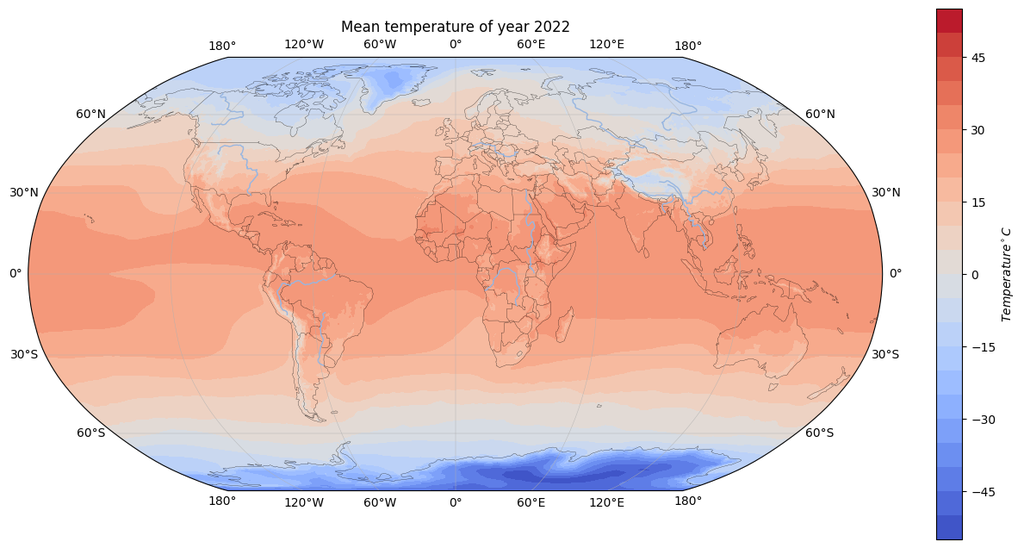

```python
temperature =  data['t2m']
yearly_temp = temperature.mean(dim='time')

# Create a Cartopy Mercator projection
projection = ccrs.Robinson()

# Create the figure and axis
plt.figure(figsize=(16,8))
ax = plt.axes(projection=ccrs.Robinson())

# Add map features
ax.add_feature(cf.COASTLINE, linewidth=0.2)
ax.add_feature(cf.BORDERS, linewidth=0.2)
ax.add_feature(cf.RIVERS)
ax.gridlines(draw_labels=True, linewidth=0.3)

# Plot the contour map of annual precipitation
cs = ax.contourf(data['longitude'], data['latitude'], (yearly_temp - 273.15), np.linspace(-55, 55, 23),cmap='coolwarm' , transform=ccrs.PlateCarree())

# Add a colorbar
cbar = plt.colorbar(cs, ax=ax, orientation='vertical', pad=0.05)
cbar.set_label('$Temperature {^\circ}C$')

# Set the plot title
plt.title('Mean temperature of year 2022')

# Show the plot
plt.show()
```

# 3. Plotting Contourplot using Precipitation data

Now, its time to plot a real climate data with everything you learned earlier. For this, we use [2022 Precipitation data](https://drive.google.com/file/d/1Q5mzA7aDhRA2baMLZ71eio-ZFHQ3mGNN/view?usp=sharing) over Bangladesh and its sorrounding region.

## importing libraries.

The following cell will first uninstall some libraries and then reinstall the specified version.

last two line will clear the output screen.

```python
!pip uninstall -y shapely
!pip uninstall -y importlib-metadata
!pip install shapely==1.7.1 --no-binary shapely
!pip install importlib-metadata==4.13.0
!pip install cartopy==0.21
from google.colab import output
output.clear()
```

After installing new python libraries, runtime needs to be restared. You can do it maually or run the following cell to kill this runtime. Then run the next cell, that will automatically connect the runtime and run.

```python
import os
os.kill(os.getpid(), 9)
```

```python
import numpy as np
import xarray as xr
import matplotlib.pyplot as plt
import cartopy.crs as ccrs
import cartopy.feature as cf
import calendar
import requests
```

## Download and load data

We specify the URL in the **file_url** variable.

Next, we make a request to the URL using **requests.get()**. The response object contains the content of the file.

We then open a file in binary write mode **("wb")** at the desired location **("/content/data.nc")** and write the content of the response into it.

Finally, we use **xr.open_dataset()** from xarray to open the downloaded file and load it into the data variable. You can replace "/content/data.nc" with your desired file path.

After executing this code, we have the data loaded into the data variable, and proceed with further analysis or operations using xarray.

```python
file_url = "https://drive.google.com/uc?id=1Q5mzA7aDhRA2baMLZ71eio-ZFHQ3mGNN&export=download"
file_path = "/content/data.nc"

response = requests.get(file_url)
with open(file_path, "wb") as f:
    f.write(response.content)

data = xr.open_dataset(file_path).load()
data
```

```
<xarray.Dataset>
Dimensions:    (longitude: 29, latitude: 33, time: 8760)
Coordinates:
  * longitude  (longitude) float32 87.0 87.25 87.5 87.75 ... 93.5 93.75 94.0
  * latitude   (latitude) float32 28.0 27.75 27.5 27.25 ... 20.5 20.25 20.0
  * time       (time) datetime64[ns] 2022-01-01 ... 2022-12-31T23:00:00
Data variables:
    u10        (time, latitude, longitude) float32 0.8939 1.087 ... -1.246
    v10        (time, latitude, longitude) float32 -0.4852 -1.151 ... -0.8678
    tp         (time, latitude, longitude) float32 1.02e-05 2.856e-05 ... 0.0
Attributes:
    Conventions:  CF-1.6
    history:      2023-06-02 13:06:47 GMT by grib_to_netcdf-2.25.1: /opt/ecmw...
```

## Seasonal spatial distribution.

1. **Extracting precipitation data for a whole year:** In this step, the code extracts the precipitation data from the loaded dataset. It multiplies the **'tp'** variable by 1000 to convert the unit from meters to millimeters. The longitude and latitude values are also extracted from the dataset.
2. **Converting hourly data to daily data:** Here, the code resamples the precipitation data from hourly to daily frequency using the **.resample(**) method with a time frequency of '1D'. It then calculates the sum of precipitation for each day using the **.sum()** method.
3. **Calculating the seasonal spatial distribution:** Here, the code defines a list of season names **(seasons)** and a corresponding list of lists **(season_months)** containing the month indices for each season. The months are grouped as Winter (DJF: December, January, February), Pre-monsoon (MAM: March, April, May), Monsoon (JJA: June, July, August), and Post-monsoon (SON: September, October, November).
4. **Calculating the seasonal mean precipitation:** This code snippet calculates the mean precipitation for each season. It iterates over the **season_months** list, selects the corresponding data from daily_precipitation using **.sel()** and the **isin()** method to match the months, and then calculates the mean along the time dimension **(dim='time')** using **.mean()**. The seasonal mean precipitation values are stored in the **seasonal_means** list.

These operations help extract the precipitation data for a whole year, convert it to daily data, and calculate the seasonal mean precipitation for each predefined season.

```python
# Extract the precipitation data for a whole year
precipitation = data['tp'] * 1000
lon = data['longitude']
lat = data['latitude']

# Convert hourly data to daily data
daily_precipitation = precipitation.resample(time='1D').sum()

# Seasonal Spatial Distribution
seasons = ['Winter (DJF)', 'Pre-monsoon (MAM)', 'Monsoon (JJA)', 'Post-monsoon (SON)']  # Winter, Spring, Summer, Autumn
season_months = [[12, 1, 2], [3, 4, 5], [6, 7, 8], [9, 10, 11]]

# Calculate the seasonal mean precipitation
seasonal_means = []
for months in season_months:
    seasonal_data = daily_precipitation.sel(time=daily_precipitation['time.month'].isin(months))
    seasonal_mean = seasonal_data.mean(dim='time')
    seasonal_means.append(seasonal_mean)
```

This code generates a 2x2 grid of subplots, where each subplot represents the seasonal spatial distribution of precipitation. Let's break it down step by step:

1. **Create the subplots:** The **plt.subplots()** function is used to create a figure with a grid of subplots. The nrows=2, ncols=2 arguments specify a 2x2 grid, and **figsize=(12, 12)** sets the size of the figure. The subplot_kw parameter sets the projection to **ccrs.PlateCarree()**, which is a map projection for visualizing global data.
2. **Plot each seasonal mean precipitation:** Using a loop, each subplot is accessed individually **(ax)**. The **contourf()** function is used to plot the seasonal mean precipitation data **(seasonal_means[i])** on each subplot. Additional features such as coastlines, borders, ocean, lakes, land, and rivers are added using **add_feature()**. The map extent is set using **set_extent(min_lon, max_lon, min_lat, max_lat)**, and gridlines are drawn with **gridlines()**.
3. **Add colorbar and subplot titles:** A vertical colorbar is added to each subplot using **colorbar()**. Subplot titles **(seasons[i])** are set using **set_title()**. The colorbar ticks and label font sizes are customized.
4. **Set the figure title and adjust layout:** The overall figure title is set using **suptitle()**. The layout is adjusted using **tight_layout()** to optimize spacing between subplots.
5. **Display the plot:** Finally, **plt.show()** is called to display the plot.

Executing this code will generate a figure with four subplots, each showing the seasonal spatial distribution of precipitation. The color of the contourf plot represents the precipitation amount, and the colorbar provides a reference for the precipitation values in millimeters per day.

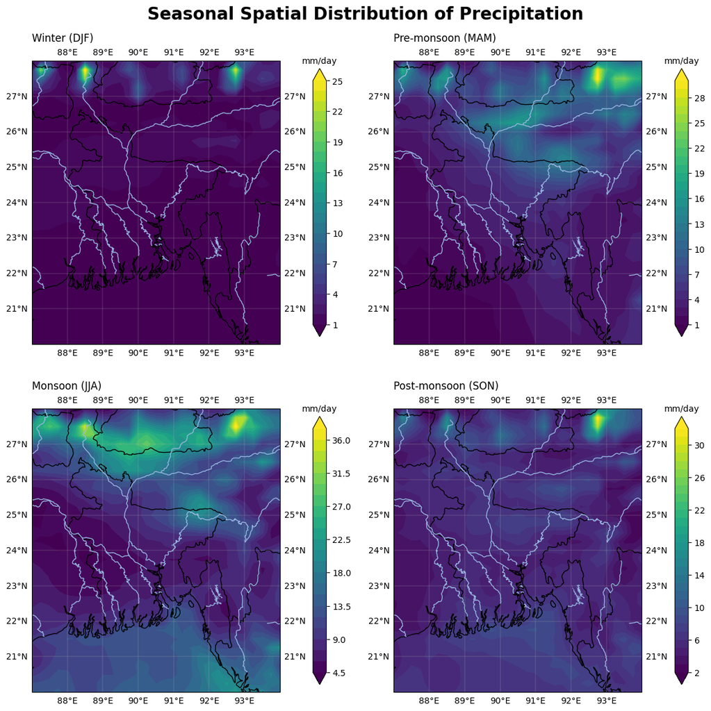

```python
# Create the subplots
fig, axs = plt.subplots(nrows=2, ncols=2, figsize=(12, 12),
                        subplot_kw={'projection': ccrs.PlateCarree()})

# Plot each seasonal mean precipitation on the subplots
for i, ax in enumerate(axs.flat):
    cs = ax.contourf(lon, lat, seasonal_means[i], 30, extend='both', transform=ccrs.PlateCarree())
    ax.add_feature(cf.COASTLINE)
    ax.add_feature(cf.BORDERS, linewidth=1)
    ax.add_feature(cf.OCEAN)
    ax.add_feature(cf.LAKES)
    ax.add_feature(cf.LAND)
    ax.add_feature(cf.RIVERS)
    ax.set_extent([87, 94, 20, 28])
    bx = ax.gridlines(draw_labels=True, linewidth=0.2)
    ax.set_title(seasons[i], fontsize=12, pad=10, y=1.04, loc="left")

    # Add vertical colorbar to each subplot with a custom size
    cbar = plt.colorbar(cs, ax=ax, orientation='vertical', pad=0.1, shrink=0.8)
    cbar.ax.tick_params(labelsize=10)
    cbar.ax.set_title('mm/day', fontsize=10)

# Add a title to the figure
fig.suptitle('Seasonal Spatial Distribution of Precipitation', fontsize=20, fontweight='bold')

# Adjust the spacing between subplots and display the plot
plt.tight_layout()

plt.show()
```

## Temporal distribution plot

Executing this code will calculate the monthly total precipitation, compute the mean precipitation for each month, and plot the temporal distribution of precipitation. The resulting plot will show the variation of precipitation over the months, providing insights into the seasonal patterns of precipitation.

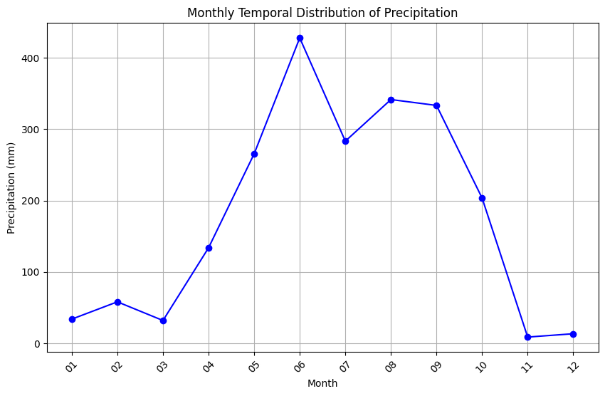

```python
# Calculate the monthly total precipitation
monthly_precipitation = daily_precipitation.resample(time='1M').sum(dim='time')

#Calculate the mean precipitation for each month
mean_monthly_precipitation = np.mean(np.mean(monthly_precipitation, axis=2), axis=1)

# Get the month labels
months = [str(month).split('-')[1] for month in monthly_precipitation['time'].values]

# Plot the temporal distribution of precipitation
plt.figure(figsize=(10, 6))
plt.plot(months, mean_monthly_precipitation, marker='o', linestyle='-', color='blue')
plt.xlabel('Month')
plt.ylabel('Precipitation (mm)')
plt.title('Monthly Temporal Distribution of Precipitation')
plt.grid(True)
plt.xticks(rotation=45)
plt.show()
```

# 4. Choosing colorbars

Colormaps are extremely useful tool for plotting scientic data.They are used to make visualization look more appealing as well as self explanatory.

### Classes of colormaps

#### Sequential

- Sequential color maps are used to represent data that varies continuously from low to high values.
- They are suitable for visualizing data such as temperature, elevation, or concentration, where there is a clear ordering and progression from one end of the color map to the other.
- Examples of sequential color maps include "viridis", "plasma", "inferno", and "cividis".
- These color maps typically have a perceptually uniform progression of colors, ensuring that the visual changes are consistent and proportional to the data values. *Sequential color maps are often used in **heatmaps, contour plots, and line plots** to represent the magnitude or intensity of a variable.

[figure not shown]

##### Example

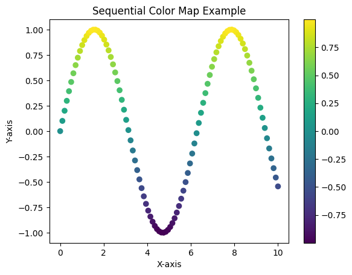

```python
import matplotlib.pyplot as plt
import numpy as np

# Generate random data
x = np.linspace(0, 10, 100)
y = np.sin(x)

# Create a sequential color map
cmap = 'viridis'

# Plot the data using the color map
plt.scatter(x, y, c=y, cmap=cmap)

# Add a color bar
plt.colorbar()

# Set title and labels
plt.title('Sequential Color Map Example')
plt.xlabel('X-axis')
plt.ylabel('Y-axis')

# Show the plot
plt.show()
```

#### Diverging Color Maps

- Diverging color maps are used to represent data that has a critical midpoint or a point of interest from which values diverge in both positive and negative directions.
- They are suitable for visualizing data such as temperature anomalies, differences from a reference value, or any data where positive and negative deviations are meaningful.
- Diverging color maps have distinct colors for positive and negative values, with a neutral color representing the midpoint or reference value.
- Examples of diverging color maps include "RdBu", "coolwarm", and "seismic".
- Diverging color maps are commonly used in **heatmaps, contour plots, and scatter plots** to highlight deviations from a baseline or central value.

[figure not shown]

##### Example

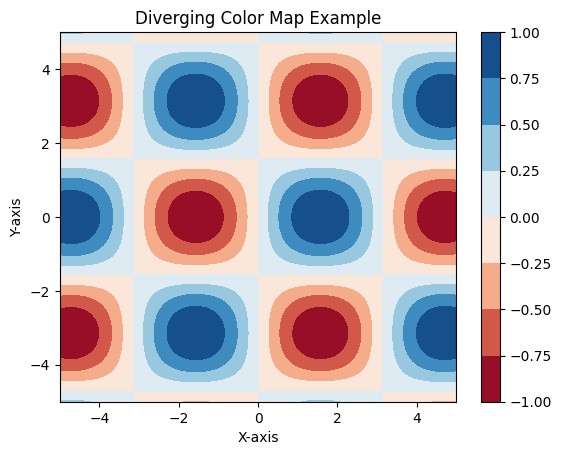

```python
import matplotlib.pyplot as plt
import numpy as np

# Generate random data
x = np.linspace(-5, 5, 100)
y = np.linspace(-5, 5, 100)
X, Y = np.meshgrid(x, y)
Z = np.sin(X) * np.cos(Y)

# Create a diverging color map
cmap = 'RdBu'

# Plot the data using the color map
plt.contourf(X, Y, Z, cmap=cmap)

# Add a color bar
plt.colorbar()

# Set title and labels
plt.title('Diverging Color Map Example')
plt.xlabel('X-axis')
plt.ylabel('Y-axis')

# Show the plot
plt.show()
```

#### Qualitative Color Maps:

- Qualitative color maps are used to represent categorical or discrete data without an inherent order or progression.
- They are suitable for visualizing data such as different classes or categories, where the color assignment does not convey any quantitative information.
- Qualitative color maps have a set of distinct colors with no specific ordering. Examples of qualitative color maps include "tab10", "tab20", and "Set3".
- Qualitative color maps are often used in **bar charts, pie charts, and scatter plots** to differentiate different groups or categories.

[figure not shown]

##### Example

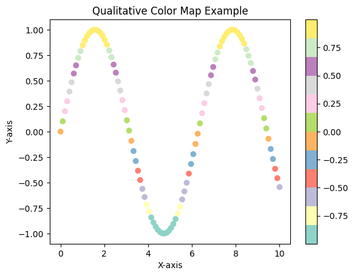

```python
import matplotlib.pyplot as plt
import numpy as np

# Generate random data
x = np.linspace(0, 10, 100)
y = np.sin(x)

# Create a qualitative color map
cmap = 'Set3'

# Plot the data using the color map
plt.scatter(x, y, c=y, cmap=cmap)

# Add a color bar
plt.colorbar()

# Set title and labels
plt.title('Qualitative Color Map Example')
plt.xlabel('X-axis')
plt.ylabel('Y-axis')

# Show the plot
plt.show()
```